# BCR release v001 prelim for annotation team

Bo Sun - Bashford Rogers Group, Wellcome Centre of Human Genetics

2020-10-20

This is a markdown to summarise the layout for the following tables:

- Contig quality control (“/well/combat/shared/B_chains_prelim/bcr_release_v001_contig_qc.csv.gz”)
- Heavy chain annotations (“/well/combat/shared/B_chains_prelim/bcr_release_v001_HC_table.csv.gz”)
- Light chain annotations (“/well/combat/shared/B_chains_prelim/bcr_release_v001_LC_table.csv.gz”)
- Merged chain annotations (“/well/combat/shared/B_chains_prelim/bcr_release_v001_chainmerge_table.csv.gz”)
- Heavy chain ranked umis - *for annotation team use* (“/well/combat/shared/B_chains_prelim/bcr_release_v001_umis_HC.csv.gz”)
- Light chain ranked umis - *for annotation team use* (“/well/combat/shared/B_chains_prelim/bcr_release_v001_umis_LC.csv.gz”)

# Contig quality control

Procedure:

- All contigs are assigned a rank order per cell barcode after splitting into Heavy and Light chain contigs. Where there are more than 1 contigs per Heavy or Light chain locus, the top two ranked contigs are selected and a rank UMI ratio is calculated (rank2_umis/rank1_umis).
- The knee point of the log ranked UMI ratios is then taken (lower bound ratio set as 0.1) as the threshold for assigning contig confidence as a VDJ singlet vs doublet. Inflection point was determined as a ratio of 0.125.
- Where the clonal identity (identical VJpairing and CDR3 aa sequence) is matched for rank1 and rank2 contigs that are IGHM/IGHD, both contigs are retained.
- This table contains all productive cellranger-filtered contigs that indexed to a study ID. This includes all possible barcodes including those from other cell type annotations and can facilitate detection of T/B VDJ doublets.

# Column description

1. barcode_seq
- Concatenated barcode and gplex IDs
2. locus
- Heavy vs. Light chain
3. contig_id
- Assembled contig_ids, unique per cell barcode
4. contig_qc
- **singleton** = only one assembled contig passed cellranger quality control per cell
- **passed_qc** = more than 2 contigs were detected, but the ratio of rank2_umis/rank1_umis was below the threshold of 0.125 and thus has sufficient confidence to be called a singlet.
- **potential_doublet** = more than 2 contigs were detected and the ratio of rank2_umis/rank1_umis was above the cutoff of 0.125 and thus had insufficient confidence to be called a singlet.
5. vdj_complete
- TRUE or FALSE
- Here TRUE are contigs where no truncations were detected in the 5’ and 3’ of the VDJ region.  
  *For the BCR analysis we are only using complete VDJs to allow for robust mutation analysis*

```r
head(contig_qc)
```

| barcode_seq | locus | contig_id | contig_qc | vdj_complete |
| --- | --- | --- | --- | --- |
| AAACCTGAGAACAATC-1-gPlexK3 | Light | AAACCTGAGAACAATC-1_contig_1 | singleton | TRUE |
| AAACCTGAGAAGAAGC-1-gPlexC3 | Light | AAACCTGAGAAGAAGC-1_contig_1 | singleton | TRUE |
| AAACCTGAGAATTCCC-1-gPlexC6 | Heavy | AAACCTGAGAATTCCC-1_contig_2 | singleton | TRUE |
| AAACCTGAGAATTCCC-1-gPlexC6 | Light | AAACCTGAGAATTCCC-1_contig_1 | potential_doublet | TRUE |
| AAACCTGAGAATTCCC-1-gPlexC6 | Light | AAACCTGAGAATTCCC-1_contig_3 | potential_doublet | TRUE |
| AAACCTGAGAATTCCC-1-gPlexC6 | Light | AAACCTGAGAATTCCC-1_contig_4 | potential_doublet | TRUE |

# VDJ annotation tables

Procedure:

- Filtered fasta file output from cellranger were aggregated and split into files of length 1E06. These were run on [IMGT High V-Quest](http://www.imgt.org/IMGTindex/IMGTHighV-QUEST.php).
- Outputs were parsed with custom function from script Parse_IMGT.R (adapted from BCellR - Bo Sun unpublished); this function removes non-productive contigs and concatenates all IMGToutputs utilising only columns that were heuristically deemed as relevant to the planned quality control/analysis.
- Metadata such as c_gene (Ig isotype/subclass), umis, reads etc. were gathered from cellranger filtered annotations and indexed on barcode and gplex.

Structure:

Annotations are split across 3 tables:

- Heavy chain: bcr_release_v001_HC_table.csv.gz
- Light chain: bcr_release_v001_LC_table.csv.gz
- Merged: bcr_release_v001_chainmerge_table.csv.gz

Preprocessing:

- The heavy chain table has had potential doublets removed as only annotations used in the BCR analysis are kept. Where cell contigs “passed_qc”, the top ranked contig was kept
- The light chain table has the same preprocessing as the heavy, but potential doublets were kept (on the basis that 1% of B cells may express dual light chains). These may be considered “low priority” as the confidence for physiological relevance is less robust.
- For the merged table, both tables were merged using barcode and gplex (barcode_seq) for indexing. Respective annotations for heavy or light chains were labelled with column name suffixes "_HC" or "_LC" to aid identification of specific chain annotations.

For detailed IMGT annotation descriptions please refere to: [IMGT documentation](http://www.imgt.org/IMGT_vquest/user_guide).

Anything that remains unclear please contact Bo Sun, Bashford-Rogers Group, WHG: bo.sun@well.ox.ac.uk

```r
head(HC)
```

| barcode_seq | locus_HC | umis_HC | umi_ranks_HC | contig_id_HC | contig_qc_HC | barcode_HC | gplex_HC | seq_ID_HC | functionality_HC | v_call_HC | v_score_HC | v_identity_HC | potential_indels_HC | v_comment_HC | v_ins_HC | v_del_HC | j_call_HC | j_score_HC | j_identity_HC | j_comment_HC | junction_frame_HC | analysed_length_HC | v_alignment_HC | sequence_alignment_HC | v_partial_missing_HC | v_uncertain_nt_HC | j_partial_missing_HC | d_j_region_HC | v_region_HC | … |
| --- | --- | --- | --- | --- | --- | --- | --- | --- | --- | --- | --- | --- | --- | --- | --- | --- | --- | --- | --- | --- | --- | --- | --- | --- | --- | --- | --- | --- | --- | --- |
| ACACTGATCCTCTAGC-1-gPlexA1 | Heavy | 17 | 1 | ACACTGATCCTCTAGC-1_contig_2 | singleton | ACACTGATCCTCTAGC-1 | gPlexA1 | 791873_GX06 | productive | Homsap IGHV3-21*01 F | 1435 | 100.00 | NA | NA | NA | NA | Homsap IGHJ6*02 F | 220 | 83.87 | NA | in-frame | 599 | gaggtgcagctggtggagtctggggga...ggcctggtcaagcctggggggtccctgagactctcctgtgcagcctctggattcaccttc............agtagctatagcatgaactgggtccgccaggctccagggaaggggctggagtgggtctcatccattagtagtagt......agtagttacatatacta… | gaggtgcagctggtggagtctggggga...ggcctggtcaagcctggggggtccctgagactctcctgtgcagcctctggattcaccttc............agtagctatagcatgaactgggtccgccaggctccagggaaggggctggagtgggtctcatccattagtagtagt......agtagttacatatacta… | 0 | 0 | 0 | actatgatagtagtagctacggtatggacgtctggggccaagggaccacggtcaccgtctcctca | gaggtgcagctggtggagtctgggggaggcctggtcaagcctggggggtccctgagactc…… | … |
| GACTACAGTGGTAACG-1-gPlexC1 | Heavy | 29 | 1 | GACTACAGTGGTAACG-1_contig_3 | singleton | GACTACAGTGGTAACG-1 | gPlexC1 | 791874_GX08 | productive | Homsap IGHV4-34*01 F | 1420 | 100.00 | NA | NA | NA | NA | Homsap IGHJ4*02 F | 222 | 95.83 | NA | in-frame | 543 | caggtgcagctacagcagtggggcgca...ggactgttgaagccttcggagaccctgtccctcacctgcgctgtctatggtgggtccttc............agtggttactactggagctggatccgccagcccccagggaaggggctggagtggattggggaaatcaatcatagt.........ggaagcaccaacta… | caggtgcagctacagcagtggggcgca...ggactgttgaagccttcggagaccctgtccctcacctgcgctgtctatggtgggtccttc............agtggttactactggagctggatccgccagcccccagggaaggggctggagtggattggggaaatcaatcatagt.........ggaagcaccaacta… | 0 | 0 | 0 | gtatagcagcagctggttaacgaaggggccttactttgactactggggccagggaaccctggtcaccgtctcctcag | caggtgcagctacagcagtggggcgcaggactgttgaagccttcggagaccctgtccctc…… | … |
| ATTGGACGTCTCCCTA-1-gPlexC1 | Heavy | 42 | 1 | ATTGGACGTCTCCCTA-1_contig_2 | singleton | ATTGGACGTCTCCCTA-1 | gPlexC1 | 791874_GX08 | productive | Homsap IGHV5-51*01 F | 1435 | 100.00 | NA | NA | NA | NA | Homsap IGHJ3*02 F | 232 | 96.00 | NA | in-frame | 552 | gaggtgcagctggtgcagtctggagca...gaggtgaaaaagcccggggagtctctgaagatctcctgtaagggttctggatacagcttt............accagctactggatcggctgggtgcgccagatgcccgggaaaggcctggagtggatggggatcatctatcctggt......gactctgataccagata… | gaggtgcagctggtgcagtctggagca...gaggtgaaaaagcccggggagtctctgaagatctcctgtaagggttctggatacagcttt............accagctactggatcggctgggtgcgccagatgcccgggaaaggcctggagtggatggggatcatctatcctggt......gactctgataccagata… | 0 | 0 | 0 | ctacggtgactacgtaggtgcttttgatatctggggccaagggacaatggtcaccgtctcttcag | gaggtgcagctggtgcagtctggagcagaggtgaaaaagcccggggagtctctgaagatc…… | … |
| CACACAACACCGGAAA-1-gPlexC1 | Heavy | 29 | 1 | CACACAACACCGGAAA-1_contig_3 | singleton | CACACAACACCGGAAA-1 | gPlexC1 | 791874_GX08 | productive | Homsap IGHV5-10-1*01 F | 1435 | 100.00 | NA | NA | NA | NA | Homsap IGHJ6*02 F | 238 | 87.10 | NA | in-frame | 605 | gaagtgcagctggtgcagtctggagca...gaggtgaaaaagcccggggagtctctgaggatctcctgtaagggttctggatacagcttt............accagctactggatcagctgggtgcgccagatgcccgggaaaggcctggagtggatggggaggattgatcctagt......gactcttataccaacta… | gaagtgcagctggtgcagtctggagca...gaggtgaaaaagcccggggagtctctgaggatctcctgtaagggttctggatacagcttt............accagctactggatcagctgggtgcgccagatgcccgggaaaggcctggagtggatggggaggattgatcctagt......gactcttataccaacta… | 0 | 0 | 0 | tagtggctacgattactggggactgtacggtatggacgtctggggccaagggaccacggtcaccgtctcctca | gaagtgcagctggtgcagtctggagcagaggtgaaaaagcccggggagtctctgaggatc…… | … |
| CCTACCAAGCAGCGTA-1-gPlexC1 | Heavy | 25 | 1 | CCTACCAAGCAGCGTA-1_contig_4 | passed_qc | CCTACCAAGCAGCGTA-1 | gPlexC1 | 791874_GX08 | productive | Homsap IGHV1-8*01 F | 1435 | 100.00 | NA | NA | NA | NA | Homsap IGHJ3*01 F | 151 | 78.00 | NA | in-frame | 589 | caggtgcagctggtgcagtctggggct...gaggtgaagaagcctggggcctcagtgaaggtctcctgcaaggcttctggatacaccttc............accagttatgatatcaactgggtgcgacaggccactggacaagggcttgagtggatgggatggatgaaccctaac......agtggtaacacaggcta… | caggtgcagctggtgcagtctggggct...gaggtgaagaagcctggggcctcagtgaaggtctcctgcaaggcttctggatacaccttc............accagttatgatatcaactgggtgcgacaggccactggacaagggcttgagtggatgggatggatgaaccctaac......agtggtaacacaggcta… | 0 | 0 | 0 | tatagcagcagctggtactcccccggacgtctggggccaagggaccacggtcaccgtctcctcag | caggtgcagctggtgcagtctggggctgaggtgaagaagcctggggcctcagtgaaggtc…… | … |
| GACTACATCTTGTTTG-1-gPlexC1 | Heavy | 3663 | 1 | GACTACATCTTGTTTG-1_contig_2 | singleton | GACTACATCTTGTTTG-1 | gPlexC1 | 791874_GX08 | productive (see comment) | Homsap IGHV3-30*04 F, or Homsap IGHV3-30-3*03 F | 1210 | 92.83 | NA | potentially, because of detected insertion/deletion | NA | in CDR2-IMGT, from codon 65 of V-REGION: 9 nucleotides (from position 348 in the user submitted sequence), (do not cause frameshift) | Homsap IGHJ4*02 F | 186 | 87.50 | NA | in-frame | 713 | caggtgcagctgttggagtctggggga...ggcgtggtccagcccgggaggtccctgagactctcctgtgtagcctctggattcaccttc............agtagtcatgctatgcactgggtccgccaggctccaggcaaggggctggagtggctggctattatatcatatgat......ggaactact........… | caggtgcagctgttggagtctggggga...ggcgtggtccagcccgggaggtccctgagactctcctgtgtagcctctggattcaccttc............agtagtcatgctatgcactgggtccgccaggctccaggcaaggggctggagtggctggctattatatcatatgat......ggaactact........… | 0 | 0 | 0 | ttacttcaacctcttctgagatcgactactggggccagggaaccctggtcaccgtctcctcag | caggtgcagctgttggagtctgggggaggcgtggtccagcccgggaggtccctgagactc…… | … |

```r
head(LC)
```

| barcode_seq | locus_LC | umis_LC | umi_ranks_LC | contig_id_LC | contig_qc_LC | functionality_LC | v_call_LC | v_score_LC | v_identity_LC | potential_indels_LC | v_comment_LC | v_ins_LC | v_del_LC | j_call_LC | j_score_LC | j_identity_LC | j_comment_LC | junction_frame_LC | analysed_length_LC | v_alignment_LC | sequence_alignment_LC | v_partial_missing_LC | v_uncertain_nt_LC | j_partial_missing_LC | d_j_region_LC | v_region_LC | j_region_LC | junction_nt_LC | sequence_LC | … |
| --- | --- | --- | --- | --- | --- | --- | --- | --- | --- | --- | --- | --- | --- | --- | --- | --- | --- | --- | --- | --- | --- | --- | --- | --- | --- | --- | --- | --- | --- | --- |
| AAACCTGAGAACAATC-1-gPlexK3 | Light | 56 | 1 | AAACCTGAGAACAATC-1_contig_1 | singleton | productive | Homsap IGLV3-25*03 F | 1192 | 92.11 | NA | NA | NA | NA | Homsap IGLJ2*01 F, or Homsap IGLJ3*01 F | 149 | 89.19 | NA | in-frame | 649 | tcctatgagctgacacagccaccctcg...gtgtcagtgtccccaagacagacggccacgatcacctgctctggggatgcattgcga..................aggcaatatggttactggtaccagcagaggccaggccaggcccctgtcttgttgatatataaggat.....................catgagag… | tcctatgagctgacacagccaccctcg...gtgtcagtgtccccaagacagacggccacgatcacctgctctggggatgcattgcga..................aggcaatatggttactggtaccagcagaggccaggccaggcccctgtcttgttgatatataaggat.....................catgagag… | 0 | 0 | 0 | NA | tcctatgagctgacacagccaccctcggtgtcagtgtccccaagacagacggccacgatc…… | gtggtcttcggcggagggaccaaattgaccgtcctac | tgtcaatcatcagacagcagtgggacctatgtggtcttc | tcctatgagctgacacagccaccctcggtgtcagtgtccccaagacagacggccacgatc…… | … |
| AAACCTGAGAATTCCC-1-gPlexC6 | Light | 44 | 1 | AAACCTGAGAATTCCC-1_contig_1 | potential_doublet | productive | Homsap IGKV1-39*01 F, or Homsap IGKV1D-39*01 F | 1390 | 100.00 | NA | NA | NA | NA | Homsap IGKJ3*01 F | 190 | 100.00 | NA | in-frame | 548 | gacatccagatgacccagtctccatcctccctgtctgcatctgtaggagacagagtcaccatcacttgccgggcaagtcagagcatt..................agcagctatttaaattggtatcagcagaaaccagggaaagcccctaagctcctgatctatgctgca.....................tccagttt… | gacatccagatgacccagtctccatcctccctgtctgcatctgtaggagacagagtcaccatcacttgccgggcaagtcagagcatt..................agcagctatttaaattggtatcagcagaaaccagggaaagcccctaagctcctgatctatgctgca.....................tccagttt… | 0 | 0 | 0 | NA | gacatccagatgacccagtctccatcctccctgtctgcatctgtaggagacagagtcacc…… | attcactttcggccctgggaccaaagtggatatcaaac | tgtcaacagagttacagtaccccattcactttc | gacatccagatgacccagtctccatcctccctgtctgcatctgtaggagacagagtcacc…… | … |
| AAACCTGAGAATTCCC-1-gPlexC6 | Light | 6 | 2 | AAACCTGAGAATTCCC-1_contig_4 | potential_doublet | productive | Homsap IGLV2-8*01 F | 1336 | 96.18 | NA | NA | NA | NA | Homsap IGLJ2*01 F, or Homsap IGLJ3*01 F or Homsap IGLJ3*02 F | 157 | 94.29 | NA | in-frame | 545 | cagtctgccctgactcagcctccctcc...gcgtccgggtctcctggacagtcagtcaccatctcctgcactggaaccaggagtgacgttggt.........ggttataactttgtctcctggtaccaacaactcccaggtaaagcccccaaactcatcatttatgaggtc.....................gctaagcg… | cagtctgccctgactcagcctccctcc...gcgtccgggtctcctggacagtcagtcaccatctcctgcactggaaccaggagtgacgttggt.........ggttataactttgtctcctggtaccaacaactcccaggtaaagcccccaaactcatcatttatgaggtc.....................gctaagcg… | 0 | 0 | 0 | NA | cagtctgccctgactcagcctccctccgcgtccgggtctcctggacagtcagtcaccatc…… | ggtcttcggcggaggaaccaagctgaccgtcctag | tgcaactcatatgcaggcggcaacaatttggtcttc | cagtctgccctgactcagcctccctccgcgtccgggtctcctggacagtcagtcaccatc…… | … |
| AAACCTGAGACCTTTG-1-gPlexB6 | Light | 215 | 1 | AAACCTGAGACCTTTG-1_contig_1 | singleton | productive | Homsap IGKV3-11*01 F | 1381 | 99.64 | NA | NA | NA | NA | Homsap IGKJ4*01 F | 190 | 100.00 | NA | in-frame | 554 | gaaattgtgttgacacagtctccagccaccctgtctttgtctccaggggaaagagccaccctctcctgcagggccagtcagagtgtt..................agcagctacttagcctggtaccaacagaaacctggccaggctcccaggctcctcatctatgatgca.....................tccaacag… | gaaattgtgttgacacagtctccagccaccctgtctttgtctccaggggaaagagccaccctctcctgcagggccagtcagagtgtt..................agcagctacttagcctggtaccaacagaaacctggccaggctcccaggctcctcatctatgatgca.....................tccaacag… | 0 | 0 | 0 | NA | gaaattgtgttgacacagtctccagccaccctgtctttgtctccaggggaaagagccacc…… | gctcactttcggcggagggaccaaggtggagatcaaac | tgtcagcaccgtagcaactggccgctcactttc | gaaattgtgttgacacagtctccagccaccctgtctttgtctccaggggaaagagccacc…… | … |
| AAACCTGAGACTACAA-1-gPlexE7 | Light | 50 | 1 | AAACCTGAGACTACAA-1_contig_1 | singleton | productive | Homsap IGKV2-28*01 F, or Homsap IGKV2D-28*01 F | 1465 | 100.00 | NA | NA | NA | NA | Homsap IGKJ2*04 (F) | 171 | 97.22 | NA | in-frame | 565 | gatattgtgatgactcagtctccactctccctgcccgtcacccctggagagccggcctccatctcctgcaggtctagtcagagcctcctgcatagt...aatggatacaactatttggattggtacctgcagaagccagggcagtctccacagctcctgatctatttgggt.....................tctaatcg… | gatattgtgatgactcagtctccactctccctgcccgtcacccctggagagccggcctccatctcctgcaggtctagtcagagcctcctgcatagt...aatggatacaactatttggattggtacctgcagaagccagggcagtctccacagctcctgatctatttgggt.....................tctaatcg… | 0 | 0 | 0 | NA | gatattgtgatgactcagtctccactctccctgcccgtcacccctggagagccggcctcc…… | agttttggccaggggaccaagctggagatcaaac | tgcatgcaagctctacaaactcctcggagtttt | gatattgtgatgactcagtctccactctccctgcccgtcacccctggagagccggcctcc…… | … |
| AAACCTGAGAGCCCAA-1-gPlexC5 | Light | 33 | 1 | AAACCTGAGAGCCCAA-1_contig_2 | singleton | productive | Homsap IGKV1-5*03 F | 1390 | 100.00 | NA | NA | NA | NA | Homsap IGKJ2*01 F | 190 | 100.00 | NA | in-frame | 555 | gacatccagatgacccagtctccttccaccctgtctgcatctgtaggagacagagtcaccatcacttgccgggccagtcagagtatt..................agtagctggttggcctggtatcagcagaaaccagggaaagcccctaagctcctgatctataaggcg.....................tctagttt… | gacatccagatgacccagtctccttccaccctgtctgcatctgtaggagacagagtcaccatcacttgccgggccagtcagagtatt..................agtagctggttggcctggtatcagcagaaaccagggaaagcccctaagctcctgatctataaggcg.....................tctagttt… | 0 | 0 | 0 | NA | gacatccagatgacccagtctccttccaccctgtctgcatctgtaggagacagagtcacc…… | gtacacttttggccaggggaccaagctggagatcaaac | tgccaacagtataatagttattcgtacactttt | gacatccagatgacccagtctccttccaccctgtctgcatctgtaggagacagagtcacc…… | … |

```r
head(merge)
```

| barcode_seq | locus_HC | umis_HC | umi_ranks_HC | contig_id_HC | contig_qc_HC | barcode_HC | gplex_HC | seq_ID_HC | functionality_HC | v_call_HC | v_score_HC | v_identity_HC | potential_indels_HC | v_comment_HC | v_ins_HC | v_del_HC | j_call_HC | j_score_HC | j_identity_HC | j_comment_HC | junction_frame_HC | analysed_length_HC | v_alignment_HC | sequence_alignment_HC | v_partial_missing_HC | v_uncertain_nt_HC | j_partial_missing_HC | d_j_region_HC | v_region_HC | … |
| --- | --- | --- | --- | --- | --- | --- | --- | --- | --- | --- | --- | --- | --- | --- | --- | --- | --- | --- | --- | --- | --- | --- | --- | --- | --- | --- | --- | --- | --- | --- |
| AAACCTGAGAATTCCC-1-gPlexC6 | Heavy | 27 | 1 | AAACCTGAGAATTCCC-1_contig_2 | singleton | AAACCTGAGAATTCCC-1 | gPlexC6 | 791874_GX68 | productive | Homsap IGHV4-59*01 F | 1420 | 100 | NA | NA | NA | NA | Homsap IGHJ4*02 F | 195 | 89.58 | NA | in-frame | 550 | caggtgcagctgcaggagtcgggccca...ggactggtgaagccttcggagaccctgtccctcacctgcactgtctctggtggctccatc............agtagttactactggagctggatccggcagcccccagggaagggactggagtggattgggtatatctattacagt.........gggagcaccaacta… | caggtgcagctgcaggagtcgggccca...ggactggtgaagccttcggagaccctgtccctcacctgcactgtctctggtggctccatc............agtagttactactggagctggatccggcagcccccagggaagggactggagtggattgggtatatctattacagt.........gggagcaccaacta… | 0 | 0 | 0 | gcatattgtggtggtgattgctattgggcctatgactactggggccagggaaccctggtcaccgtctcctcag | caggtgcagctgcaggagtcgggcccaggactggtgaagccttcggagaccctgtccctc…… | … |
| AAACCTGAGACTACAA-1-gPlexE7 | Heavy | 13 | 1 | AAACCTGAGACTACAA-1_contig_2 | singleton | AAACCTGAGACTACAA-1 | gPlexE7 | 791986_GX82 | productive | Homsap IGHV4-59*01 F | 1420 | 100 | NA | NA | NA | NA | Homsap IGHJ6*03 F | 265 | 91.94 | NA | in-frame | 582 | caggtgcagctgcaggagtcgggccca...ggactggtgaagccttcggagaccctgtccctcacctgcactgtctctggtggctccatc............agtagttactactggagctggatccggcagcccccagggaagggactggagtggattgggtatatctattacagt.........gggagcaccaacta… | caggtgcagctgcaggagtcgggccca...ggactggtgaagccttcggagaccctgtccctcacctgcactgtctctggtggctccatc............agtagttactactggagctggatccggcagcccccagggaagggactggagtggattgggtatatctattacagt.........gggagcaccaacta… | 0 | 0 | 0 | tgtagtagtaccagctgctcgtaactactactactacatggacgtctggggcaaagggaccacggtcaccgtctcctca | caggtgcagctgcaggagtcgggcccaggactggtgaagccttcggagaccctgtccctc…… | … |
| AAACCTGAGAGCCCAA-1-gPlexC5 | Heavy | 37 | 1 | AAACCTGAGAGCCCAA-1_contig_1 | singleton | AAACCTGAGAGCCCAA-1 | gPlexC5 | 791874_GX56 | productive | Homsap IGHV4-34*01 F | 1420 | 100 | NA | NA | NA | NA | Homsap IGHJ5*02 F | 219 | 92.16 | NA | in-frame | 542 | caggtgcagctacagcagtggggcgca...ggactgttgaagccttcggagaccctgtccctcacctgcgctgtctatggtgggtccttc............agtggttactactggagctggatccgccagcccccagggaaggggctggagtggattggggaaatcaatcatagt.........ggaagcaccaacta… | caggtgcagctacagcagtggggcgca...ggactgttgaagccttcggagaccctgtccctcacctgcgctgtctatggtgggtccttc............agtggttactactggagctggatccgccagcccccagggaaggggctggagtggattggggaaatcaatcatagt.........ggaagcaccaacta… | 0 | 0 | 0 | tcgaggaggtggttcgacccctggggccagggaaccctggtcaccgtctcctcag | caggtgcagctacagcagtggggcgcaggactgttgaagccttcggagaccctgtccctc…… | … |
| AAACCTGAGATAGTCA-1-gPlexK5 | Heavy | 9 | 1 | AAACCTGAGATAGTCA-1_contig_1 | singleton | AAACCTGAGATAGTCA-1 | gPlexK5 | 791988_GX51 | productive | Homsap IGHV3-9*01 F | 1435 | 100 | NA | NA | NA | NA | Homsap IGHJ3*02 F | 250 | 100.00 | NA | in-frame | 576 | gaagtgcagctggtggagtctggggga...ggcttggtacagcctggcaggtccctgagactctcctgtgcagcctctggattcaccttt............gatgattatgccatgcactgggtccggcaagctccagggaagggcctggagtgggtctcaggtattagttggaat......agtggtagcataggcta… | gaagtgcagctggtggagtctggggga...ggcttggtacagcctggcaggtccctgagactctcctgtgcagcctctggattcaccttt............gatgattatgccatgcactgggtccggcaagctccagggaagggcctggagtgggtctcaggtattagttggaat......agtggtagcataggcta… | 0 | 0 | 0 | tatagcagcctttggaatgatgcttttgatatctggggccaagggacaatggtcaccgtctcttcag | gaagtgcagctggtggagtctgggggaggcttggtacagcctggcaggtccctgagactc…… | … |
| AAACCTGAGATCACGG-1-gPlexK7 | Heavy | 34 | 1 | AAACCTGAGATCACGG-1_contig_2 | singleton | AAACCTGAGATCACGG-1 | gPlexK7 | 791988_GX75 | productive | Homsap IGHV1-2*02 F | 1435 | 100 | NA | NA | NA | NA | Homsap IGHJ5*02 F | 246 | 98.04 | NA | in-frame | 581 | caggtgcagctggtgcagtctggggct...gaggtgaagaagcctggggcctcagtgaaggtctcctgcaaggcttctggatacaccttc............accggctactatatgcactgggtgcgacaggcccctggacaagggcttgagtggatgggatggatcaaccctaac......agtggtggcacaaacta… | caggtgcagctggtgcagtctggggct...gaggtgaagaagcctggggcctcagtgaaggtctcctgcaaggcttctggatacaccttc............accggctactatatgcactgggtgcgacaggcccctggacaagggcttgagtggatgggatggatcaaccctaac......agtggtggcacaaacta… | 0 | 0 | 0 | tagcagcagctggtaccattcaaaaatccctctacagcaactggttcgacccctggggccagggaaccctggtcaccgtctcctcag | caggtgcagctggtgcagtctggggctgaggtgaagaagcctggggcctcagtgaaggtc…… | … |
| AAACCTGAGATGAGAG-1-gPlexD3 | Heavy | 20 | 1 | AAACCTGAGATGAGAG-1_contig_1 | singleton | AAACCTGAGATGAGAG-1 | gPlexD3 | 791985_GX33 | productive | Homsap IGHV3-23*01 F, or Homsap IGHV3-23D*01 F | 1435 | 100 | NA | NA | NA | NA | Homsap IGHJ3*02 F | 250 | 100.00 | NA | in-frame | 572 | gaggtgcagctgttggagtctggggga...ggcttggtacagcctggggggtccctgagactctcctgtgcagcctctggattcaccttt............agcagctatgccatgagctgggtccgccaggctccagggaaggggctggagtgggtctcagctattagtggtagt......ggtggtagcacatacta… | gaggtgcagctgttggagtctggggga...ggcttggtacagcctggggggtccctgagactctcctgtgcagcctctggattcaccttt............agcagctatgccatgagctgggtccgccaggctccagggaaggggctggagtgggtctcagctattagtggtagt......ggtggtagcacatacta… | 0 | 0 | 0 | attactatgatagtagtgggtgatgcttttgatatctggggccaagggacaatggtcaccgtctcttcag | gaggtgcagctgttggagtctgggggaggcttggtacagcctggggggtccctgagactc…… | … |

# Additional files for annotation team

Additional Heavy and Light chain ranked contig (based on umis) tables are provided for annotation team’s usage for doublet identification.

Contig ranks are split across two tables:

- Heavy chain - bcr_release_v001_umis_HC.csv.gz
- Light chain - bcr_release_v001_umis_LC.csv.gz

*Only the top 2 ranked umis were kept for annotation team, as lower ranked umis correspond to ambient RNA*

```r
head(HC_all)
```

| barcode_seq | contig_id | umis_HC | pct_immunoglobin | umi_ranks | contig_qc |
| --- | --- | --- | --- | --- | --- |
| AAACCTGAGAATTCCC-1-gPlexC6 | AAACCTGAGAATTCCC-1_contig_2 | 27 | 0.9784736 | 1 | singleton |
| AAACCTGAGACAGAGA-1-gPlexE6 | AAACCTGAGACAGAGA-1_contig_2 | 3849 | 58.3185568 | 1 | singleton |
| AAACCTGAGACCTTTG-1-gPlexB6 | AAACCTGAGACCTTTG-1_contig_2 | 27 | 4.2747022 | 1 | potential_doublet |
| AAACCTGAGACCTTTG-1-gPlexB6 | AAACCTGAGACCTTTG-1_contig_3 | 11 | 4.2747022 | 2 | potential_doublet |
| AAACCTGAGACTACAA-1-gPlexE7 | AAACCTGAGACTACAA-1_contig_2 | 13 | 0.8709422 | 1 | singleton |
| AAACCTGAGAGCCCAA-1-gPlexC5 | AAACCTGAGAGCCCAA-1_contig_1 | 37 | 2.6018100 | 1 | singleton |

```r
head(LC_all)
```

| barcode_seq | contig_id | umis_LC | pct_immunoglobin | umi_ranks | contig_qc |
| --- | --- | --- | --- | --- | --- |
| AAACCTGAGAACAATC-1-gPlexK3 | AAACCTGAGAACAATC-1_contig_1 | 56 | 2.20276758 | 1 | singleton |
| AAACCTGAGAAGAAGC-1-gPlexC3 | AAACCTGAGAAGAAGC-1_contig_1 | 4 | 0.07494379 | 1 | singleton |
| AAACCTGAGAATTCCC-1-gPlexC6 | AAACCTGAGAATTCCC-1_contig_1 | 44 | 0.97847358 | 1 | potential_doublet |
| AAACCTGAGAATTCCC-1-gPlexC6 | AAACCTGAGAATTCCC-1_contig_4 | 6 | 0.97847358 | 2 | potential_doublet |
| AAACCTGAGACAGAGA-1-gPlexE6 | AAACCTGAGACAGAGA-1_contig_1 | 10214 | 58.31855678 | 1 | singleton |
| AAACCTGAGACCTTTG-1-gPlexB6 | AAACCTGAGACCTTTG-1_contig_1 | 215 | 4.27470217 | 1 | singleton |

In order to identify plasmablast/plasma cells from non-plasma B cells, immunoglobulin(Ig) gene umis can be plotted either has a histogram, or against pct_immunoglobin (metric from preprocessing pipeline):

- Non-plasmablast/plasma cells are typically low in Ig gene umis (ranging from ~3-100) and this correlates nicely with GEX pct_immunoglobulin.
- Plasmablast/plasma cells are typically high in Ig gene umis >100.

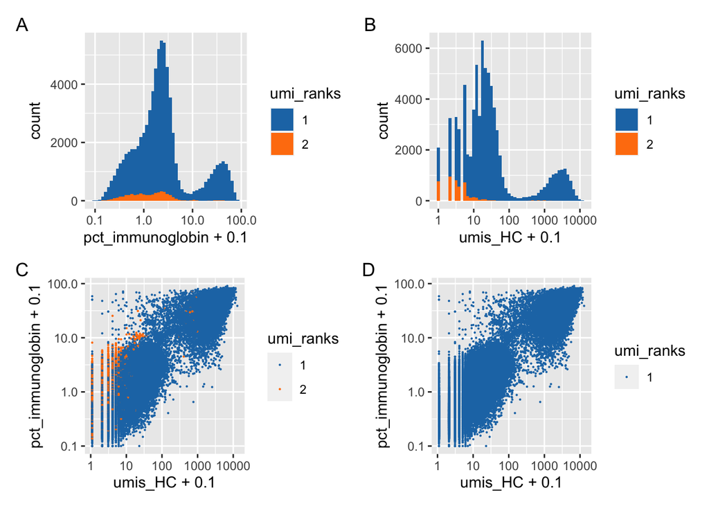

```r
A <- HC_all %>%
  mutate(umi_ranks = as.factor(umi_ranks)) %>%
  ggplot(aes(pct_immunoglobin + 0.1, fill = umi_ranks)) +
  geom_histogram(bins = 50)+
  scale_x_log10()+
  ggsci::scale_fill_d3()

B <- HC_all %>%
  mutate(umi_ranks = as.factor(umi_ranks)) %>%
  ggplot(aes(umis_HC + 0.1, fill = umi_ranks)) +
  geom_histogram(bins  =50)+
  scale_x_log10()+
  ggsci::scale_fill_d3()

C <- HC_all %>%
  mutate(umi_ranks = as.factor(umi_ranks)) %>%
  ggplot(aes(umis_HC + 0.1, pct_immunoglobin + 0.1, color = umi_ranks)) +
  geom_point(size = 0.1)+
  scale_y_log10()+
  scale_x_log10()+
  ggsci::scale_color_d3()

D <-  HC_all %>%
  mutate(umi_ranks = as.factor(umi_ranks)) %>%
  filter(contig_qc != "potential_doublet") %>%
  ggplot(aes(umis_HC + 0.1, pct_immunoglobin + 0.1, color=umi_ranks)) +
  geom_point(size = 0.1)+
  scale_y_log10()+
  scale_x_log10()+
  ggsci::scale_color_d3()

(A+B)/(C+D)+ plot_annotation(tag_levels = 'A')
```

**Figure 1.** *Only Heavy chain data is shown for simplicity but Light chain data follows the same distributions*.*All axis are log scaled*. (A) Histogram of pct_immunoglobin (Heavy chain) derived from GEX data for all cells with a productive VDJ from cellranger output. (B) Histogram of umis for productive Heavy chain contigs. (C) pct_immunoglobin vs umis_HC for all ranked contigs; colored by ranked contigs based on umis (1 = contig associated with highest umis). (D) pct_immunoglobin vs umis_HC for all contigs that passed qc.